# Our World in Multivariate Data

From twelve scatterplots to one multivariate picture of life at different levels of GDP

Vis-MLM

R

multivariate

HE plots

Our World in Data

A multivariate reanalysis of Our World in Data’s chart of life at different levels of GDP, showing what the outcomes share, what income leaves unexplained, and which countries don’t fit

Author

Michael Friendly

Published

October 30, 2026

## Introduction: a beautiful small-multiples chart

I saw this [chart on X](https://x.com/MaxCRoser/status/2115743768510886379) from [Our World In Data](https://ourworldindata.org/), relating aspects of “How is Life?” to countries’ GDP per cap. My first thought was “Wow!” that’s an excellent example of small multiples to see many variables together in a single view: 12 indicators, each one plotted against log GDP per capita, one dot per country. The message is immediate: almost all indicators of quality of life get better as countries get richer.

[figure not shown]

Figure 1: How is life at different levels of GDP per capita? (Our World in Data, CC-BY)

In his [post](https://x.com/OurWorldInData/status/2115836531894047016), Max Roser put the message this way: “Where GDP per capita is higher, living conditions are far better in many ways.” That is true, and the analysis below confirms it. But it also invites the next questions: are they better in the same way, at the same pace, and what is left over once income is accounted for?

### A multivariate view?

But it also struck me as something from which more might be learned from a multivariate perspective. Figure 1 shows 12 *separate* bivariate displays. What it can’t show:

- how the outcomes relate to *each other*, which is their joint distribution;
- whether a country that does well on one outcome, *given its GDP*, also does well on the others;
- whether the whole pattern differs by region, or changes with development.

Thinking this way, we can frame this as a “$p$ responses, one predictor” problem, i.e., a multivariate linear model (MLM):
$$f(\mathbf{Y})_{n \times p} = g(x)\,\mathbf{B}_{1 \times p} + \mathbf{E}_{n \times p} \; ,$$
where $x$ is GDP per capita. Both sides can be transformed:

- On the left, $f(\mathbf{Y}) = [f_1(\mathbf{y}_1), \dots, f_p(\mathbf{y}_p)]$ transforms each outcome separately (log, logit, …) to accommodate outcome variables measured on very different scales, and to make their relations with GDP closer to linear.
- On the right, $g(x)$ is usually just $\log(\text{GDP})$, as in the OWID chart. But it can also be a polynomial or spline in $\log(\text{GDP})$, when the relation is curved.

I call this a **doubly generalized linear model**, but that is more a conceptual term than a statistical one, because the details that give it structure need to be worked out, as in generalized linear models (Nelder and Wedderburn 1972) and generalized additive models (Hastie and Tibshirani 1986). The goal is to allow flexibility in the transformations of the predictor and the response variables that make the fitted relations linear in the parameters in $\mathbf{B}$.

The statistical questions are then about the fitted part $g(x)\mathbf{B}$ and the residual covariance $\boldsymbol{\Sigma}$ of the rows of $\mathbf{E}$. These create some interesting possibilities for visualizing these relations, using and extending the methods I describe in my book [*Visualizing Multivariate Data and Models in R*](https://friendly.github.io/Vis-MLM-book/) (Friendly 2024) and R packages [heplots](https://friendly.github.io/heplots/), [candisc](https://friendly.github.io/candisc/), [mvinfluence](https://friendly.github.io/mvinfluence/) (Friendly et al. 2026; Friendly and Fox 2026; Friendly 2026) and others.

As an added bonus, I also discovered several aspects of a multivariate approach to this problem and similar ones, that make analysis and visualization simpler or easier to understand.

A word about what I bring to this. I’m a statistician and a data visualization person, not an economist, demographer or public health expert, and I don’t know the literature on any of these measures. When I say why a country stands out, say that a country lives longer or less long than its income predicts, that comes from what the analysis and the graphs show, together with what I know in general about the countries. Take these as hypotheses to check, not as findings. I’d be glad to hear from readers who know the countries or the measures better.

I’m grateful to the team at [Our World In Data](https://ourworldindata.org/) for making these data so easy to get.

## The data

I found the data in the [OWID grapher](https://ourworldindata.org/charts) series. Each panel of Figure 1 is a standard OWID chart. For example [life expectancy](https://ourworldindata.org/grapher/life-expectancy). Every chart has a download tab, and its data are also available as a CSV file at `https://ourworldindata.org/grapher/<slug>.csv`. So it was easy to download the 12 indicators, plus GDP per capita, and merge them by country code. The script `R/get-LifeGDP.R` does this. Like the OWID chart, it takes the most recent year available for each country and indicator, and keeps only countries, not regional aggregates. That gives a data set of 198 countries.

The indicators come from many sources (UN agencies, UNESCO, Gallup, the World Bank), so not every country has every one. Water and life satisfaction have the most gaps, and literacy has a more curious problem: For many rich countries the most recent literacy figure is a historical estimate for 1950, presumably because nobody measures literacy where it is near 100%. Rather than deal with these issues here, I use the 9 indicators with the best coverage and leave out literacy, test scores and stunting. That leaves 121 countries with complete data on all 9.

The variables used in the analyses here are:

- `GDP`: GDP per capita, in constant international dollars (PPP); the predictor
- `ChildMort`: percent of children dying before age 15
- `Stillbirth`: stillbirths per 100 births
- `MatMort`: maternal deaths per 100,000 live births
- `Doctors`: physicians per 1,000 people
- `LifeExp`: life expectancy at birth, in years
- `SchoolYrs`: expected years of schooling
- `Electricity`: percent of the population with access to electricity
- `Water`: percent of the population using safely managed drinking water
- `LifeSat`: life satisfaction, on the 0–10 Cantril ladder

### Data prep

A bit of preparation makes the multivariate analyses go more smoothly:

- **Transformations.**
  - The three mortality rates are on a log scale, as in the OWID chart, and so is the number of doctors.
  - Access to electricity and safe water are percentages that pile up at 100% in richer countries, so I use an empirical logit for them, $\text{logit}(y) = \log \left[ (y + 0.5) / (100 - y + 0.5) \right]$, where $y$ is the percentage. Adding 0.5 keeps the values at exactly 100% finite.
- **Orientation.** Child mortality, stillbirths and maternal mortality are “bad” outcomes, where lower is better. I reverse them (using $-\log$), so that higher means better on *every* response, in contrast to Figure 1, where you have to think about what direction is better. This small step makes every later display, from correlation matrices to biplots, much easier to read: all the arrows and ellipses point the same semantic way.
- **Standardization.** For the multivariate models the responses are standardized to $z$-scores, so that no single indicator dominates because of its units.

Finally, for comparisons among regions I use OWID’s continents. Only one country from Oceania has complete data, so I merged it with Asia.

```r
knitr::kable(as.data.frame(table(Region = cc$region)))
```

Countries in the complete-case analysis, by region

| Region | Freq |
| --- | --- |
| Africa | 27 |
| Asia/Oceania | 38 |
| Europe | 40 |
| North America | 8 |
| South America | 8 |

## Development profiles: From twelve panels to one

Small multiples invite comparison *within* a panel. Comparing *across* panels is harder: each panel in Figure 1 has its own vertical scale and units, so it is hard to say whether electricity or life expectancy “responds” to income sooner in relation to $\log(GDP)$

A first step is to add a smoother to each panel. Figure 2 does this for the top two rows of Figure 1, using a [loess](https://en.wikipedia.org/wiki/Local_regression) curve, with the three rates on a log scale as in the OWID chart. Stunting (the “Hunger” panel in OWID) is one of the indicators I leave out of the later analyses. The curves bring out what the clouds of points only suggest: these relations are not straight lines. Doctors is the clearest case, staying near zero up to about $10,000, then climbing steeply, and falling back among the richest countries. Smoothers help you read each panel, but they don’t make it any easier to compare one panel with another.

**Show the code for the smoothed panels**

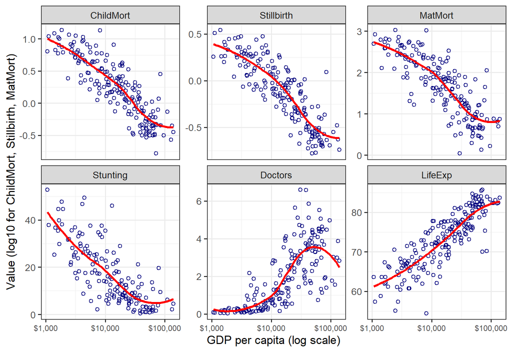

Figure 2: The top two rows of the OWID chart, redrawn from the data with a loess smoother added to each panel.

```r
# The top two rows of the OWID chart, with a loess smoother added to each panel
panels <- c("ChildMort", "Stillbirth", "MatMort", "Stunting", "Doctors", "LifeExp")
LifeGDP |>
  select(GDP, all_of(panels)) |>
  mutate(across(c(ChildMort, Stillbirth, MatMort), log10)) |>
  pivot_longer(all_of(panels), names_to = "indicator", values_to = "value") |>
  mutate(indicator = factor(indicator, levels = panels)) |>
  ggplot(aes(GDP, value)) +
  geom_point(shape = 1, colour = "navy") +
  geom_smooth(method = "loess", formula = y ~ x, se = FALSE, colour = "red") +
  scale_x_log10(breaks = c(1e3, 1e4, 1e5), labels = c("$1,000", "$10,000", "$100,000")) +
  facet_wrap(~ indicator, scales = "free_y") +
  labs(x = "GDP per capita (log scale)", y = "Value (log10 for ChildMort, Stillbirth, MatMort)") +
  theme(axis.text.x = element_text(size = 9))
```

One simple way to put the responses on a common footing:

1. Fit a smooth curve to each response against log GDP. I use a natural spline with 3 df, and all the countries available for that response.
2. Rescale each fitted curve to run from 0, the level predicted for the poorest countries, to 1, the level predicted for the richest.

Overlaying the rescaled curves gives Figure 3. I call these **development profiles**. Each curve shows how far a typical country at a given income has come, on that indicator, along the path from the poorest to the richest. I haven’t seen this kind of chart before. I think it could be more generally useful for this type of analysis looking at several aspects of an outcome (“good life” here) in relation to a single predictor.

**Show the code for fitting the profiles and thresholds**

```r
# Smooth fit of each (transformed) response on log GDP, using all available countries
# for each response, rescaled to [0, 1] over the observed GDP range:
# 0 = level of the poorest countries, 1 = level of the richest
grid <- data.frame(logGDP = seq(min(OW$logGDP), max(OW$logGDP), length.out = 200))

fit_profiles <- function(data) {
  lapply(resp, \(v) {
    fit <- lm(reformulate("ns(logGDP, 3)", v), data = data)
    yhat <- predict(fit, newdata = grid)
    data.frame(grid, response = v,
               fit = (yhat - min(yhat)) / (max(yhat) - min(yhat)))
  }) |> bind_rows()
}

# "development threshold": GDP where the fitted profile first reaches 10/50/90% of its range
fit_thresholds <- function(profiles) {
  profiles |>
    group_by(response) |>
    summarise(half = logGDP[which(fit >= 0.5)[1]],
              q10  = logGDP[which(fit >= 0.1)[1]],
              q90  = logGDP[which(fit >= 0.9)[1]]) |>
    arrange(half) |>
    mutate(response = factor(response, levels = response))
}

profiles <- fit_profiles(OW)
thresholds <- fit_thresholds(profiles)
profiles$response <- factor(profiles$response, levels = levels(thresholds$response))

# GDP values for inline text, e.g. `r usd(thr50["Water"])`
usd <- function(x) paste0("\\$", format(round(x, -2), big.mark = ",", trim = TRUE))
thr50 <- setNames(10^thresholds$half, thresholds$response)
```

**Show the code for plotting the profiles**

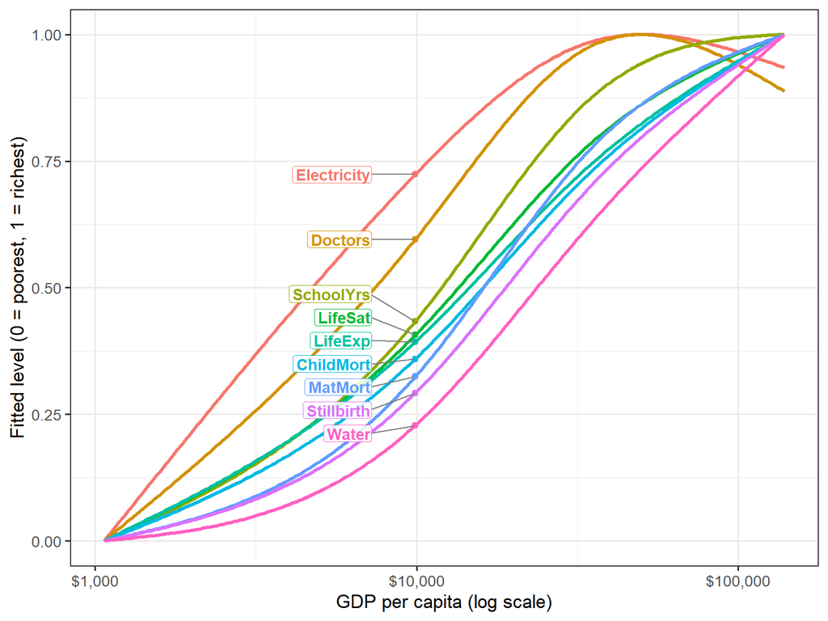

Figure 3: Development profiles: spline fit of each response on log GDP, rescaled to [0, 1].

```r
dollar_log <- scale_x_continuous(breaks = 3:5, labels = c("$1,000", "$10,000", "$100,000"))

# label each curve at GDP = $10,000, where the curves are spread out; right-justified
# labels just left of the curve, with white boxes so the curves don't run through the text
lab10k <- profiles |>
  group_by(response) |>
  slice_min(abs(logGDP - 4), n = 1, with_ties = FALSE) |>
  ungroup()

ggplot(profiles, aes(logGDP, fit, colour = response)) +
  geom_line(linewidth = 1.1) +
  geom_point(data = lab10k, size = 1.8) +
  geom_label_repel(data = lab10k, aes(label = response), hjust = 1, direction = "y",
                   nudge_x = -0.15, xlim = c(NA, 3.92), box.padding = 0.15,
                   label.padding = 0.12, label.size = NA, fill = alpha("white", 0.85),
                   segment.colour = "grey50", size = 3.8, fontface = "bold",
                   min.segment.length = 0, seed = 1) +
  dollar_log +
  labs(x = "GDP per capita (log scale)",
       y = "Fitted level (0 = poorest, 1 = richest)") +
  theme(legend.position = "none")
```

The curves are not parallel. They come in a clear *sequence*, which is easiest to see by reading across at height 0.5:

- Access to electricity is first: halfway by about $4,800.
- Doctors come next, at $7,600.
- Schooling, life satisfaction, life expectancy and the three mortality measures form a cluster between $12,100 and $19,200.
- Safely managed drinking water comes last, at about $23,900.

Figure 4 summarizes the profiles as “development thresholds”. The dot marks the GDP at which each profile reaches half its range, and the line runs from 10% to 90%. The lines show a second difference, in how *quickly* each indicator changes. Electricity and doctors go from 10% to 90% over about a 15-fold range of GDP. Life expectancy and child mortality take more than 30-fold: they improve gradually, and keep improving, over almost the whole range of incomes.

**Show the code for plotting the thresholds**

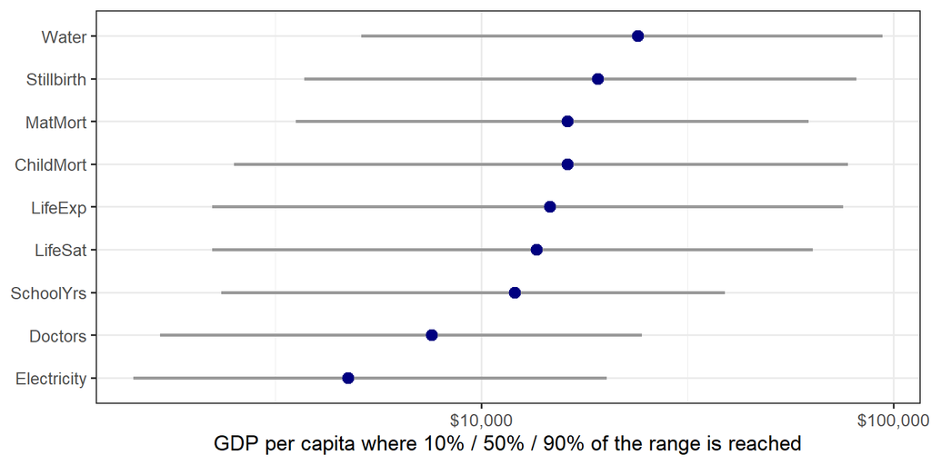

Figure 4: Development thresholds: GDP per capita at which each profile reaches 10%, 50% (dot) and 90% of its range.

```r
ggplot(thresholds, aes(y = response)) +
  geom_linerange(aes(xmin = q10, xmax = q90), linewidth = 1, colour = "grey60") +
  geom_point(aes(x = half), size = 3, colour = "navy") +
  dollar_log +
  labs(x = "GDP per capita where 10% / 50% / 90% of the range is reached",
       y = NULL)
```

It is tempting to read this as a story of *infrastructure and personnel first, outcomes later*. But a caution is needed, because the sequence depends on the scale of each response. Table 1 repeats the calculation on the original scales of the OWID chart.

```r
# Same profiles on the original scales (mortality-type outcomes only negated)
OWraw <- LifeGDP |>
  transmute(logGDP = log10(GDP), ChildMort = -ChildMort, Stillbirth = -Stillbirth,
            MatMort = -MatMort, Doctors, LifeExp, SchoolYrs, Electricity, Water, LifeSat)
thresholds_raw <- fit_thresholds(fit_profiles(OWraw))
thr50_raw <- setNames(10^thresholds_raw$half, thresholds_raw$response)
```

```r
data.frame(Transformed = usd(thr50), Rank = seq_along(thr50),
           Raw = usd(thr50_raw[names(thr50)]),
           `Raw rank` = match(names(thr50), names(thr50_raw)),
           row.names = names(thr50), check.names = FALSE) |>
  knitr::kable(align = "rrrr")
```

Table 1: GDP per capita at which each profile reaches half its range, on the transformed scales used here and on the original scales.

|  | Transformed | Rank | Raw | Raw rank |
| --- | --- | --- | --- | --- |
| Electricity | $4,800 | 1 | $3,100 | 1 |
| Doctors | $7,600 | 2 | $15,400 | 9 |
| SchoolYrs | $12,100 | 3 | $12,100 | 6 |
| LifeSat | $13,600 | 4 | $13,600 | 7 |
| LifeExp | $14,700 | 5 | $14,700 | 8 |
| ChildMort | $16,200 | 6 | $4,800 | 3 |
| MatMort | $16,200 | 7 | $4,200 | 2 |
| Stillbirth | $19,200 | 8 | $7,400 | 4 |
| Water | $23,900 | 9 | $11,800 | 5 |

Life expectancy, schooling and life satisfaction were not transformed, so their thresholds don’t change. The rest change a lot:

- **The mortality measures** move from the middle of the sequence to near the front. On the raw scale, most of the *absolute* reduction in child deaths happens early: going from 10% to 2% of children dying before age 15 covers most of the range. On a log scale, going from 2% to 0.4% counts just as much, and that further improvement continues well into the high-income range.
- **Doctors** go the other way, from second to last. On the raw scale the number of physicians per 1,000 hardly changes until about $10,000, then rises steeply, which is how it looks in the OWID panel. On the log scale the large *proportional* increases among poor countries dominate.
- **Safely managed water** moves from last to the middle, from $23,900 to $11,800. The median country has about 70% coverage by $10,000–30,000 and 99% above that, so on the raw scale much of the range is covered at middle incomes. The logit stretches out the top of the scale: going from 90% to 99% counts about as much as going from 50% to 90%, and that last step comes late.

Neither version is “right”. A log scale measures relative change and a raw scale measures absolute change, and which matters depends on the question. For the multivariate analyses that follow, I chose the transformations to make the relations closer to linear and the variances more similar. But it’s worth knowing that this choice also changes the story a display tells.

One more detail: the Electricity and Doctors profiles turn *down* slightly at the top of the GDP range. This is most likely an end effect of the spline. Only 10 countries have GDP per capita above $80,000: a mixed group of financial centers (Luxembourg, Singapore, Ireland, Switzerland), petro-states (Qatar, Norway) and Guyana, recently rich from oil. That is too few to pin down the shape of a curve.

## Thinking multivariately: the MLM

The development profiles were still nine separate regressions. The multivariate linear model fits them all at once. In R this needs only a matrix on the left side of the model formula. Here that is `Z`, the $121 \times 9$ matrix of standardized responses for the countries with complete data. The estimated coefficients $\mathbf{B}$ are exactly the same as from nine separate `lm()` fits.

What the MLM adds are *tests* that consider all the responses *together*, taking their correlations into account. Here I use Pillai’s trace for these tests.

The first question is whether the relation with log GDP is linear when all the outcomes are considered together. To allow for curvature I use a natural spline in log GDP with 3 degrees of freedom, `ns(logGDP, 3)`, which I say more about in The spline trick below. A quick multivariate test shows that this gives a highly significant improvement over a straight line (Pillai = 0.71, $F(18, 220) = 6.72$, $p < 10^{-12}$).

```r
# Is the relation with log GDP linear, jointly over all responses?
mod1 <- lm(Z ~ logGDP, data = cc)
mod2 <- lm(Z ~ ns(logGDP, 3), data = cc)
anova(mod1, mod2)
```

```
#> Analysis of Variance Table
#>
#> Model 1: Z ~ logGDP
#> Model 2: Z ~ ns(logGDP, 3)
#>   Res.Df Df Gen.var.  Pillai approx F num Df den Df   Pr(>F)
#> 1    119     0.18462
#> 2    117 -2  0.16925 0.70941   6.7183     18    220 2.49e-13 ***
#> ---
#> Signif. codes:  0 '***' 0.001 '**' 0.01 '*' 0.05 '.' 0.1 ' ' 1
```

Table 2 shows that this curvature is not spread evenly across the responses. Access to electricity gains the most (.62 to .74), followed by doctors (.70 to .77). These are the two profiles that bend most in Figure 3. Electricity saturates even on the logit scale, and doctors turn down among the richest countries. The mortality measures, water and schooling gain less, .02 to .04, from the gentler S-shapes of their profiles. Only for life expectancy and life satisfaction does a straight line in log GDP do about as well as a curve.

```r
rsq <- function(mod) sapply(summary(mod), \(s) s$r.squared)
tab_rsq <- data.frame(linear = rsq(mod1), spline = rsq(mod2), row.names = resp)
tab_rsq$diff <- tab_rsq$spline - tab_rsq$linear
knitr::kable(round(tab_rsq, 2))
```

Table 2: R² for each response: linear in log GDP, natural spline with 3 df, and their difference

|  | linear | spline | diff |
| --- | --- | --- | --- |
| ChildMort | 0.78 | 0.81 | 0.03 |
| Stillbirth | 0.77 | 0.81 | 0.04 |
| MatMort | 0.70 | 0.73 | 0.03 |
| Doctors | 0.70 | 0.77 | 0.06 |
| LifeExp | 0.75 | 0.75 | 0.01 |
| SchoolYrs | 0.67 | 0.69 | 0.02 |
| Electricity | 0.62 | 0.74 | 0.12 |
| Water | 0.74 | 0.77 | 0.03 |
| LifeSat | 0.66 | 0.66 | 0.01 |

### Does region matter?

The next question is whether region matters, *beyond* GDP. With `region` as a 5-level factor, the standard analysis formally becomes multivariate analysis of covariance (MANCOVA), or a test of homogeneity of regressions depending on your perspective for what you want to account for first.

As before, I use the natural spline in log GDP, to allow for non-linearity, as the covariate. Both terms are highly significant (Pillai = 1.26 for GDP and 1.33 for region, both $p < 10^{-15}$). Adding region raises $R^2$ for every response. The largest gains are for maternal mortality (.73 to .82), doctors (.77 to .85) and electricity (.74 to .85).

```r
# Does region matter, beyond GDP?  And is the GDP slope the same in all regions?
modR <- lm(Z ~ ns(logGDP, 3) + region, data = cc)
Anova(modR)
```

```
#>
#> Type II MANOVA Tests: Pillai test statistic
#>               Df test stat approx F num Df den Df    Pr(>F)
#> ns(logGDP, 3)  3    1.2582   8.5882     27    321 < 2.2e-16 ***
#> region         4    1.3308   5.9831     36    432 < 2.2e-16 ***
#> ---
#> Signif. codes:  0 '***' 0.001 '**' 0.01 '*' 0.05 '.' 0.1 ' ' 1
```

The region coefficients, relative to Africa, are positive for nearly every response. At the same level of GDP, African countries do worse on almost all of these outcomes. Europe is furthest ahead on the mortality measures, nearly one standard deviation. Life satisfaction gives the largest regional difference: North and South America are 1.06 and 0.82 SD above Africa, at the same GDP. This fits the high happiness scores often noted for Latin America. The HE plots in the next section show these region differences directly.

### Equal slopes for regions?

Last, a MANCOVA assumes that the slopes are the same in every region. That is, it assumes that the GDP gradient is the same in Africa as in Europe. Adding a GDP × region interaction tests this, and the assumption is rejected (Pillai = 0.66, $F(36, 416) = 2.30$, $p < .0001$). Two caveats apply:

- This test allows only the *linear* part of the GDP slope to differ by region.
- North and South America have only 8 countries each, so their slopes are poorly estimated.

```r
modRI <- lm(Z ~ ns(logGDP, 3) + region + logGDP:region, data = cc)
anova(modR, modRI)
```

```
#> Analysis of Variance Table
#>
#> Model 1: Z ~ ns(logGDP, 3) + region
#> Model 2: Z ~ ns(logGDP, 3) + region + logGDP:region
#>   Res.Df Df Gen.var.  Pillai approx F num Df den Df    Pr(>F)
#> 1    113     0.14385
#> 2    109 -4  0.13710 0.66349   2.2979     36    416 5.449e-05 ***
#> ---
#> Signif. codes:  0 '***' 0.001 '**' 0.01 '*' 0.05 '.' 0.1 ' ' 1
```

The GDP slopes are not homogeneous across regions, so this is a MANCOVA with a caveat: the region effects in the additive model should be read as *average* differences, over the range of GDP where the regions overlap. I keep the additive model as a useful summary for the HE plots that follow.

## HE plots: GDP and region effects

The tests in the last section say *that* GDP and region matter, jointly over all the outcomes. They don’t say *how*. An HE plot shows this directly, for any pair of responses. It draws two kinds of ellipses:

- The **E** ellipse (red, dashed) shows the residual, or error, covariance. It is the scatter of countries around the fitted model, the data ellipse of the residuals.
- An **H** ellipse for each term in the model shows the covariance of the *fitted values* for that term. Its size and orientation show how strongly, and in which directions, the term moves the responses.

The H ellipses are scaled so that a term is significant (by Roy’s test, at $\alpha = .05$) exactly when its ellipse sticks out beyond the E ellipse somewhere. Then you can read both the significance and the direction of an effect from the same picture.

See Friendly (2007), the [heplots](https://friendly.github.io/heplots/) package, and the chapters on HE plots in my book [*Visualizing Multivariate Data and Models in R*](https://friendly.github.io/Vis-MLM-book/), for more.

### The spline trick

The model is the MANCOVA from the last section, `modR`. There is one detail worth noting. With GDP entered as a single 1-df term, $\log(\text{GDP})$, its H “ellipse” would collapse to a line: one linear predictor can push the responses in only one direction.

A trick, which I discovered from this example is to use a term, $g[\log(\text{GDP})]$ which adds an extra degree of freedom or two, to allow the relationship to bend smoothly to some degree. Consequently, the GDP **H** ellipse is allowed to get slightly fatter than a line, to the extent that the relationship differs from a strictly linear one in $\log(\text{GDP})$ relative to the transformation of the response, $f(\mathbf{y}_i)$.

Here, I use a simple *natural cubic spline*, given by `splines::ns(logGDP, df=3)`. This gives the GDP **H** ellipse some extra wiggle room to express non-linearity, if there is any in the data.

Figure 5 shows this for life expectancy and life satisfaction.

- The GDP ellipse (blue) is very long and *very* thin. Even with three degrees of freedom, GDP moves these two outcomes along essentially a single direction: up and to the right, together.
- The region ellipse (black) is much rounder. It sticks out past the E ellipse only modestly, at the upper right and lower left, so region matters here, though far less than GDP. It is tilted up and to the right, but more steeply than the GDP ellipse, so it reaches further in the life satisfaction direction.

The dots in Figure 5 need a word of explanation. By default, `heplot()` marks each region with its *raw* mean. Here that would be misleading. The region H ellipse is adjusted for GDP, but the raw means are not. They would mostly show differences in income again, lying along the GDP direction, with Africa far down at the lower left. So instead I plot the *GDP-adjusted* region means: the averages, by region, of the residuals from a model with GDP alone. Now the dots and the region ellipse show the same thing.

At the same GDP, North and South America are about 0.5 and 0.3 SD *above* average in life satisfaction, and Africa is about 0.25 SD below average in life expectancy. Europe and Asia/Oceania are close to the center: their raw advantages are mostly accounted for by income.

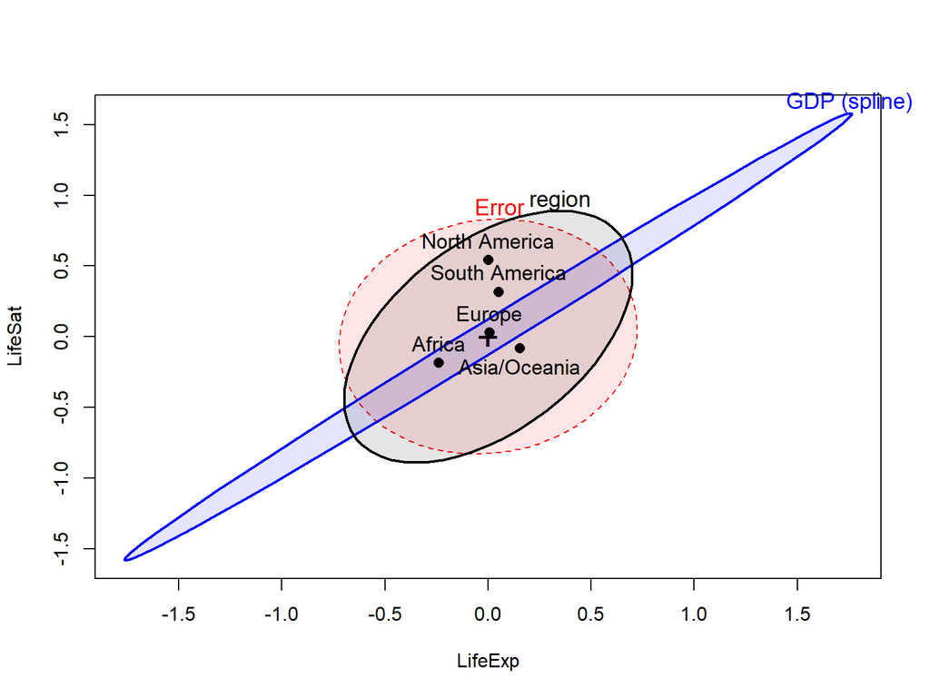

Figure 5: HE plot for LifeExp and LifeSat: GDP (spline) and region effects. Dots show GDP-adjusted region means.

```r
# GDP-adjusted responses: residuals from the model with GDP alone
res_gdp <- resid(lm(Z ~ ns(logGDP, 3), data = cc))
adj_means <- aggregate(res_gdp, list(region = cc$region), mean)

# HE plot for two responses; GDP H ellipse vs. region H ellipse, relative to E.
# Suppress the raw region means and add the GDP-adjusted ones.
vars <- c("LifeExp", "LifeSat")
heplot(modR, variables = vars, factor.means = FALSE,
       fill = TRUE, fill.alpha = 0.1, label.cex = 1.15,
       term.labels = c("GDP (spline)", "region"))
points(adj_means[, vars], pch = 16, cex = 1.2)
text(adj_means[, vars], labels = adj_means$region, pos = c(3, 1, 3, 3, 3), cex = 1.1)
```

Figure 6 extends this to five of the responses, in an HE plot matrix. Two features stand out:

- **The GDP effect is nearly one-dimensional.** Its ellipse is a thin cigar in almost every panel. Whatever the spline adds, GDP mostly moves all the outcomes along one common “development” direction. The exceptions are the panels with doctors, where the GDP ellipse is fatter. That is the curvature already seen in Figure 3: doctors turn down among the richest countries while the other outcomes keep rising.
- **The region effect is not one-dimensional.** Its ellipse is fatter, and its orientation changes from panel to panel. The regions differ in *different ways* on different outcomes, not just “better” or “worse” overall. Relative to E, region is largest in the panels with doctors or child mortality. It is smallest among life expectancy, water and life satisfaction, where its ellipse barely gets past E.

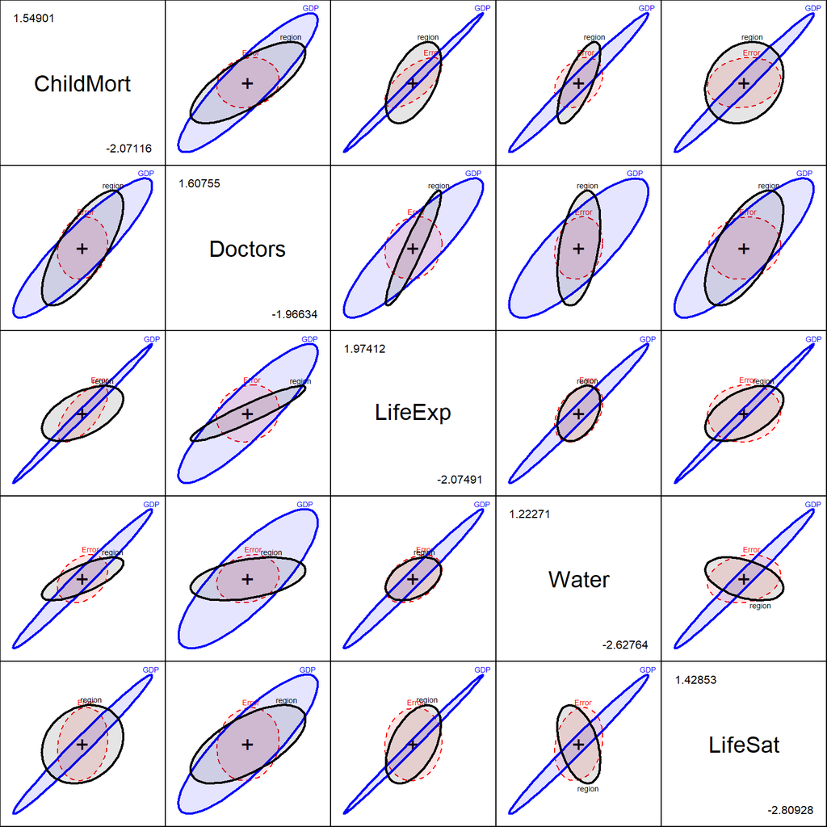

Figure 6: HE plot matrix for five responses. “GDP” labels the H ellipse for the 3-df natural spline in log GDP per capita, `ns(logGDP, 3)`, in the model.

```r
# region means are left out here: the default ones would be unadjusted for GDP
pairs(modR, variables = c("ChildMort", "Doctors", "LifeExp", "Water", "LifeSat"),
      factor.means = FALSE, fill = TRUE, fill.alpha = 0.1,
      term.labels = c("GDP", "region"))
```

With nine responses there are 36 pairwise panels, too many to look at. A canonical discriminant analysis does the summarizing for us. It finds the linear combinations of the responses that best separate the regions, relative to the within-region variation. These are the dimensions of the region H ellipsoid in the full 9-dimensional space. There can be at most four dimensions, one fewer than the number of regions.

The same problem as with the dots in Figure 5 comes up here, in a bigger way. Running `candisc()` on `modR` itself gives canonical *axes* based on the GDP-adjusted region effect. But it computes the plotted *scores* (the points, region means and data ellipses) from the raw responses, so they still contain GDP. In that version of the plot, Can1 correlates −0.86 with log GDP, and the plot mostly shows the income gradient once more, from Africa to Europe.

The fix is the same as before. I run the canonical analysis on the GDP-adjusted responses, the residuals from the model with GDP alone, with region as the only term. Now the scores are uncorrelated with GDP, and the plot shows only how the regions differ *at the same income*. The tests for region come from `modR`, in the last section. This version is for display, and its significance tests are only approximate, because it doesn’t allow for the degrees of freedom used by GDP.

```r
# Canonical view of region differences, after removing GDP:
# region model for the residuals from Z ~ ns(logGDP, 3)
modA <- lm(res_gdp ~ region, data = cc)
can_region <- candisc(modA, term = "region")
can_region
```

```
#>
#> Canonical Discriminant Analysis for region:
#>
#>     CanRsq Eigenvalue Difference Percent Cumulative
#> 1 0.458813   0.847791    0.31525 52.7649     52.765
#> 2 0.347489   0.532541    0.31525 33.1443     85.909
#> 3 0.154896   0.183286    0.31525 11.4074     97.317
#> 4 0.041333   0.043115    0.31525  2.6834    100.000
#>
#> Test of H0: The canonical correlations in the
#> current row and all that follow are zero
#>
#>   LR test stat approx F numDF  denDF   Pr(> F)
#> 1      0.28610   4.4763    36 406.46 2.152e-14 ***
#> 2      0.52865   3.2440    24 316.73 1.096e-06 ***
#> 3      0.81017   1.7442    14 220.00   0.04873 *
#> 4      0.95867   0.7976     6 111.00   0.57375
#> ---
#> Signif. codes:  0 '***' 0.001 '**' 0.01 '*' 0.05 '.' 0.1 ' ' 1
```

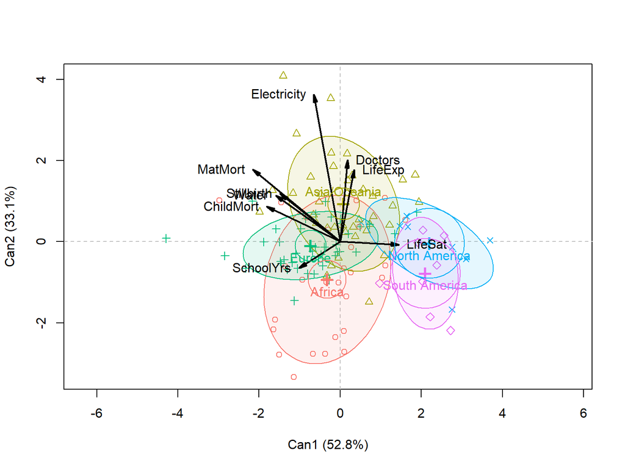

Figure 7: Canonical discriminant plot of region differences, using GDP-adjusted responses.

```r
# reverse Can1 so that right = higher life satisfaction (the Americas), and
# reverse Can2 so that up = better on electricity, doctors, life expectancy
plot(can_region, var.lwd = 2, var.col = "black", ellipse = TRUE, rev.axes = c(TRUE, TRUE),
     scale = 4, col = scales::hue_pal()(nlevels(cc$region)))
```

Two dimensions account for 86% of the GDP-adjusted region differences, and they are easy to interpret from the variable vectors.

- **Can1 (53%) sets life satisfaction against health.** To the right, the life satisfaction vector points to the Americas: the Dominican Republic, Costa Rica, Mexico, Guatemala and Guyana. To the left, the vectors for child and maternal mortality, stillbirths, water and schooling point to Europe, led by Belarus, North Macedonia, Montenegro and Ukraine, along with Egypt. For their income, Latin American countries are happier than their health outcomes would suggest, and post-communist Europe is the reverse. Both are well-known patterns in the happiness literature. Here they appear together, as two ends of the same dimension.
- **Can2 (33%) is mostly electricity**, along with doctors, life expectancy and maternal mortality. Asia/Oceania is at the top, and Africa and South America are at the bottom. The countries most above their GDP prediction are poor countries with near-universal electricity: Palestine, Tajikistan, Afghanistan, Kyrgyzstan and Lebanon. The countries most below it are all African: the Congo, Eswatini, Botswana, South Africa and Nigeria. Their GDP is high relative to their infrastructure and health, in some because of oil and minerals and in southern Africa alongside the burden of HIV/AIDS, a pattern that returns in the residual PCA below.

## What GDP doesn’t explain: residual correlations

Every outcome here is strongly related to GDP. The correlations with log GDP run from .79 for electricity to .88 for child mortality and stillbirths. So GDP acts as a *common factor*. Any two outcomes are bound to be highly correlated, just because both go up with income. The OWID chart in effect shows nine views of this one fact. The more interesting question is what is left when GDP is taken out: do the outcomes still hang together, and if so, which ones?

To answer it, I take the residuals from the MLM with the spline in log GDP, `mod2`. Each residual says how much better or worse a country does on an outcome than a typical country with the same income. Then I compare the correlations among the residuals, the *partial* correlations controlling for GDP, with the raw correlations.

```r
R_raw  <- cor(Z)
res    <- resid(mod2)
R_part <- cor(res)

# raw correlations with log GDP: the "common factor"
round(cor(Z, cc$logGDP)[, 1], 2)
```

```
#>   ChildMort  Stillbirth     MatMort     Doctors     LifeExp   SchoolYrs
#>        0.88        0.88        0.83        0.84        0.86        0.82
#> Electricity       Water     LifeSat
#>        0.79        0.86        0.81
```

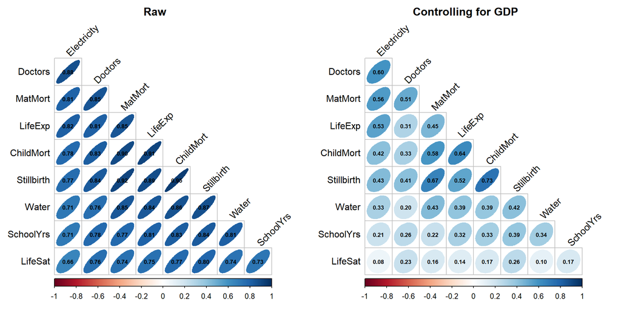

Figure 8: Correlations among responses: raw (left) and controlling for GDP (right).

```r
op <- par(mfrow = c(1, 2), mar = c(1, 1, 3, 1))
ord <- corrplot::corrMatOrder(R_part, order = "AOE")
corrplot::corrplot(R_raw[ord, ord], method = "ellipse", type = "lower", diag = FALSE,
                   tl.col = "black", tl.srt = 45, addCoef.col = "black",
                   number.cex = 0.6, title = "Raw", mar = c(0, 0, 2, 0))
corrplot::corrplot(R_part[ord, ord], method = "ellipse", type = "lower", diag = FALSE,
                   tl.col = "black", tl.srt = 45, addCoef.col = "black",
                   number.cex = 0.6, title = "Controlling for GDP", mar = c(0, 0, 2, 0))
par(op)
```

Figure 8 shows the two side by side. The variables in both panels are in the same order, found from the partial correlations, so that similar outcomes are next to each other.

- **Raw:** every correlation is large, from .66 to .95, with an average of .81. Except for life satisfaction, which is a bit weaker, there is little structure to see. Almost everything is dark blue.
- **Controlling for GDP:** the correlations drop to an average of .37, and now there is structure. They are still all *positive*. Because of the orientation step, positive means that a country doing better than expected for its income on one outcome tends to do better on the others too. Good things go together, even beyond income.

Three features stand out in the partial correlations:

- **The mortality block** (child mortality, stillbirths and maternal mortality) stays strongly correlated, at .58 to .73. Life expectancy joins it, at .64 with child mortality. This looks like a “health system” factor: beyond what income buys, some countries keep mothers and children alive better than others.
- **Electricity and doctors** stay correlated at .60, and both relate to maternal mortality (.56 and .51). Perhaps this is general state capacity: the ability to build infrastructure and staff it.
- **Life satisfaction** is nearly independent of everything else once GDP is controlled. The largest of its partial correlations is .26, and it is .08 with electricity. Happiness tracks money, across countries. But a country that is healthier, or better schooled, than its income predicts is *not* noticeably happier than its income predicts. We saw a hint of this already in the canonical analysis, where life satisfaction was set against the health outcomes.

Some of this residual structure comes from region. The residuals here adjust for GDP only. If region is controlled as well (using `modR` from above), the partial correlations shrink again, to an average of .31, and electricity–doctors drops to .46. But the mortality block and its link to life expectancy hold up (child mortality–life expectancy is .68). Life satisfaction stays isolated.

A correlation matrix shows only the *strength* of linear association. Figure 9 shows the residuals themselves for five of the outcomes. The data ellipses confirm the picture: tilted ellipses among child mortality, maternal mortality and life expectancy, and nearly circular ones in the life satisfaction row. The plots also show what the correlations hide. Two points lie far out in the lower left of the mortality and life expectancy panels. These are Nigeria and Guyana, which do much worse on child mortality and life expectancy than their GDP predicts. Points like these can drive a correlation, and I return to them in the section on unusual countries below.

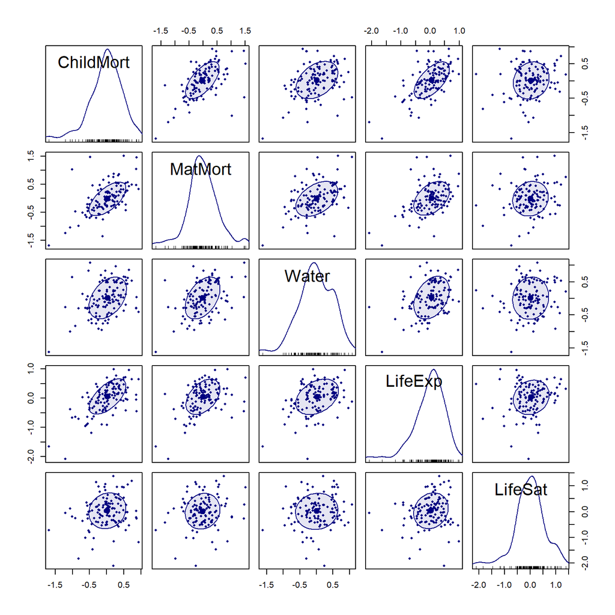

Figure 9: Scatterplot matrix of residuals from the GDP model, with 68% data ellipses.

```r
# residual scatterplot matrix with 68% data ellipses
scatterplotMatrix(res[, c("ChildMort", "MatMort", "Water", "LifeExp", "LifeSat")],
                  smooth = FALSE, regLine = FALSE,
                  ellipse = list(levels = 0.68, fill.alpha = 0.1),
                  diagonal = list(method = "density"),
                  col = "navy", pch = 16, cex = 0.6)
```

### What we learned here

These points draw on all nine outcomes in Figure 8. Figure 9 shows only five of them, so stillbirths, doctors, schooling and electricity don’t appear there.

- **All good things go together, even beyond income.** Because of the orientation step, *every* correlation is positive, raw and partial alike.
- **The mortality block stays strongly correlated.** Child mortality, stillbirths and maternal mortality look like a “health system” factor, beyond what income buys.
- **Electricity and doctors stay correlated** (.60) after GDP is controlled, perhaps an “infrastructure and state capacity” pairing.
- **Life satisfaction becomes nearly independent of the other outcomes** once GDP is controlled. Happiness tracks money, but not health or schooling *given* money.

## Doing better than your money: residual PCA and biplot

The usual first step in summarizing many correlated variables is a principal components analysis (PCA). Here, though, a PCA of the outcomes themselves has little to tell us. The first component accounts for 83% of the variance, and its scores correlate .92 with log GDP. It simply rediscovers income, the common factor that the OWID chart already puts on the horizontal axis.

```r
# PCA of the (standardized, oriented) responses: PC1 is essentially GDP
pca_y <- prcomp(Z)
summary(pca_y)$importance[, 1:4]
```

```
#>                             PC1     PC2       PC3       PC4
#> Standard deviation     2.737965 0.64566 0.5681853 0.4893487
#> Proportion of Variance 0.832940 0.04632 0.0358700 0.0266100
#> Cumulative Proportion  0.832940 0.87926 0.9151300 0.9417400
```

```r
round(cor(pca_y$x[, 1:2], cc$logGDP), 2)
```

```
#>      [,1]
#> PC1  0.92
#> PC2 -0.05
```

### The residual PCA trick

A PCA of the *residuals* from the GDP model asks a more interesting question. Which countries achieve more, or less, than their income predicts, and on which outcomes? It is the dimension-reduction view of the residual correlations in the last section.

I haven’t seen this used anywhere, but it comes from thinking about what variables to display in plots, when you want to incorporate some known variable and see what remains to be explained. Common examples of this are [**added variable** plots](https://en.wikipedia.org/wiki/Partial_regression_plot), implemented in `car::AVplots()` and my recent extension of this idea, **partial variable** plots, implemented in `heplots::pvPlot()`.

```r
# PCA of residuals from the GDP model
res <- resid(mod2)
pca_r <- prcomp(res)
# orient PC1 so that positive = better than GDP predicts
if (sum(pca_r$rotation[, 1]) < 0) {
  pca_r$rotation[, 1] <- -pca_r$rotation[, 1]
  pca_r$x[, 1] <- -pca_r$x[, 1]
}
summary(pca_r)$importance[, 1:4]
```

```
#>                              PC1      PC2       PC3       PC4
#> Standard deviation     0.9916812 0.569029 0.5188721 0.4503367
#> Proportion of Variance 0.4334300 0.142710 0.1186600 0.0893800
#> Cumulative Proportion  0.4334300 0.576140 0.6948000 0.7841800
```

```r
round(pca_r$rotation[, 1:2], 2)
```

```
#>              PC1   PC2
#> ChildMort   0.34 -0.07
#> Stillbirth  0.36  0.02
#> MatMort     0.42 -0.15
#> Doctors     0.31  0.01
#> LifeExp     0.37 -0.13
#> SchoolYrs   0.30  0.20
#> Electricity 0.37 -0.25
#> Water       0.29 -0.08
#> LifeSat     0.20  0.92
```

The residual PCA has a clear structure:

- **PC1 (43%) is a general “performance relative to income” score.** All nine loadings are positive, from .20 for life satisfaction to .42 for maternal mortality. A country with a high score does better than its GDP predicts on nearly everything, and the health outcomes and electricity count most. This is the “good things go together” result from the residual correlations, as a single score.
- **PC2 (14%) is essentially life satisfaction** (loading .92), set against electricity (−.25). It is the one outcome that, given income, goes its own way.

Figure 10 shows both together, in a biplot: points for countries, and vectors for the outcomes. The vectors for the seven health and infrastructure outcomes fan out together to the right, along PC1. Schooling tilts upward a little. Life satisfaction points almost straight up, nearly at right angles to the others, which is how a biplot shows near-zero correlation.

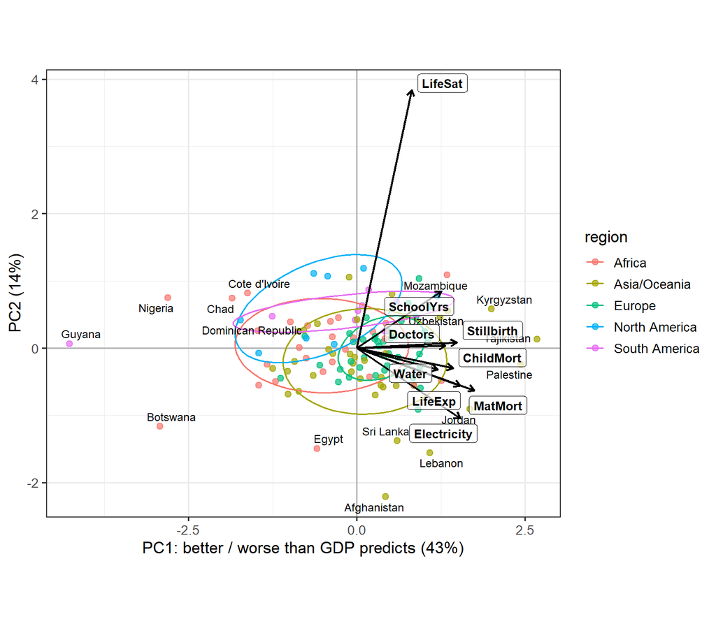

Figure 10: Biplot of residuals from the GDP model, colored by region.

```r
scores <- data.frame(cc[, c("country", "region")], pca_r$x[, 1:2])
extreme <- scores |> filter(rank(PC1) <= 6 | rank(-PC1) <= 6 | rank(-abs(PC2)) <= 4)
vscale <- 0.9 * max(abs(scores[, c("PC1", "PC2")])) / max(abs(pca_r$rotation[, 1:2]))
vecs <- data.frame(var = rownames(pca_r$rotation), vscale * pca_r$rotation[, 1:2])
pve <- round(100 * pca_r$sdev^2 / sum(pca_r$sdev^2))

ggplot(scores, aes(PC1, PC2)) +
  geom_hline(yintercept = 0, colour = "grey70") +
  geom_vline(xintercept = 0, colour = "grey70") +
  geom_point(aes(colour = region), size = 2, alpha = 0.7) +
  stat_ellipse(aes(colour = region), level = 0.68, linewidth = 0.6) +
  geom_text_repel(data = extreme, aes(label = country), size = 3.2, max.overlaps = 20) +
  geom_segment(data = vecs, aes(x = 0, y = 0, xend = PC1, yend = PC2),
               arrow = arrow(length = unit(0.2, "cm")), linewidth = 0.8) +
  geom_label_repel(data = vecs, aes(label = var), size = 3.4, fontface = "bold",
                   label.size = NA, fill = alpha("white", 0.7), min.segment.length = 1) +
  coord_equal() +
  labs(x = paste0("PC1: better / worse than GDP predicts (", pve[1], "%)"),
       y = paste0("PC2 (", pve[2], "%)"))
```

The region ellipses show where the regions fall. Europe is compact and sits to the right: few European countries do much worse than their income predicts. Africa is the most spread out, and most of the countries far to the left are African. The Americas sit a little higher than the rest on PC2, reflecting the high life satisfaction seen in the canonical analysis. At the bottom are countries with good infrastructure but very low life satisfaction for their income: Afghanistan, Lebanon, Egypt and Sri Lanka. All four have been through war or economic crisis in recent years.

Figure 11 ranks the countries by their PC1 score, showing the dozen at each end.

**Show the code for ranking the countries**

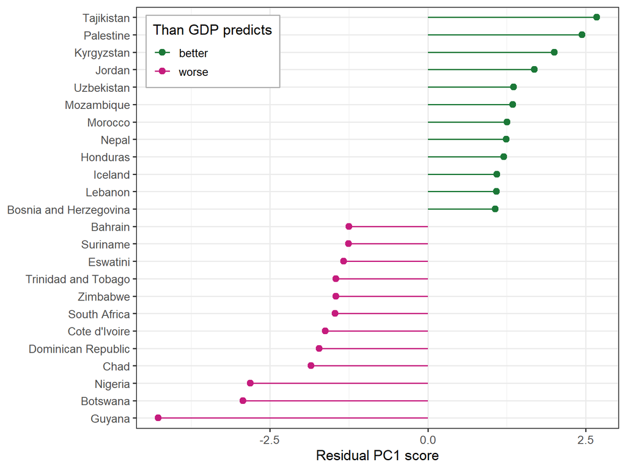

Figure 11: Countries doing most better or worse than their GDP predicts (residual PC1).

```r
# PC1 of residuals as a "performance relative to income" score
top <- scores |>
  arrange(PC1) |>
  slice(c(1:12, (n() - 11):n())) |>
  mutate(country = factor(country, levels = country),
         side = ifelse(PC1 > 0, "better", "worse"))

ggplot(top, aes(PC1, country, colour = side)) +
  geom_segment(aes(x = 0, xend = PC1, yend = country)) +
  geom_point(size = 2.5) +
  scale_colour_manual(values = c(better = "#1b7837", worse = "#c51b7d")) +
  labs(x = "Residual PC1 score", y = NULL, colour = "Than GDP predicts") +
  theme(legend.position = "inside",
        legend.position.inside = c(0.02, 0.98),
        legend.justification = c(0, 1),
        legend.background = element_rect(colour = "grey70"))
```

The *underperformers* mostly fall into two groups:

- **Resource economies:** Guyana, Nigeria, Botswana, Chad, Trinidad and Tobago, Bahrain and Suriname. In these countries GDP is driven largely by oil, gas, diamonds or other minerals, and it overstates the broad welfare that the other outcomes measure.
- **Southern Africa:** South Africa, Eswatini and Zimbabwe, along with Botswana again. These are the countries hit hardest by HIV/AIDS, which has cut life expectancy and raised mortality far below what their incomes would predict.

The other two fit less neatly. Côte d’Ivoire falls short most on doctors, life expectancy and electricity. The Dominican Republic is a different case: its shortfall is concentrated in the mortality measures and safe water, while its number of doctors is about what its income predicts.

Guyana is the extreme case, and it shows that this kind of score depends on *when* each value was measured. Guyana’s GDP per capita has multiplied several times since oil production began in 2019. Its health and infrastructure outcomes, which change slowly, have not caught up yet. The value for life satisfaction is even older, from 2011.

The *overperformers* are a more varied group:

- **Former socialist states:** Tajikistan, Kyrgyzstan, Uzbekistan, and Bosnia and Herzegovina. These may reflect a legacy of universal health care, schooling and electrification, which has outlasted the economic collapse of the 1990s.
- **The Middle East and North Africa:** Jordan, Morocco, Palestine and Lebanon. The last two need a caution. Palestine’s GDP value is for 2025, after the war in Gaza, but most of its other outcomes were measured before it. Lebanon’s income fell sharply in its economic crisis after
  2019. Some of their “overperformance” is the result of income falling faster than the other measures. Lebanon and Jordan are also below their predictions on life satisfaction.
- **Nepal and Honduras:** lower-income countries that do better than predicted on most outcomes, Nepal most on schooling and Honduras most on life satisfaction, stillbirths and child mortality.
- **Iceland** is the only rich country in the group, modestly above its prediction on everything.
- **Mozambique** is the real surprise. It is above its prediction on every outcome, and most of all on life satisfaction. It is worth checking before reading much into it.

These lists also depend on the model. If I use a quadratic in log GDP instead of the spline, the PC1 scores still correlate .93 with these, and the extreme countries stay put: Tajikistan at the top, and Guyana, Nigeria and Botswana at the bottom. But 9 of the 24 countries in Figure 11 change. Greece, Spain, Finland, Belarus, North Macedonia and New Zealand join the overperformers, and Qatar, Ghana and Sierra Leone join the underperformers. Some of this is just a matter of where the cutoff falls: Greece, Spain, Finland and Belarus rank just outside the top dozen here.

The lesson goes beyond any one country. A residual score measures performance *relative to a fitted model of GDP*. So it reflects errors or quirks in GDP, and the shape chosen for the curve, as well as real achievement in the outcomes.

## Unusual countries: multivariate outliers and influence

So far, the residuals have been summarized by correlations and principal components. This section looks at individual countries, and asks two different questions. Which countries are *unusual*, given their income? And which ones have the most *influence* on the fitted model? As we will see, these are mostly not the same countries.

### Multivariate outliers

The natural measure of how unusual a country is across all nine residuals is its squared Mahalanobis distance, $D^2$, the distance from the center of the residuals, taking their correlations into account. If the residuals are multivariate normal, $D^2$ has approximately a $\chi^2$ distribution with 9 degrees of freedom, and a QQ plot against that distribution (Figure 12) shows how well this holds.

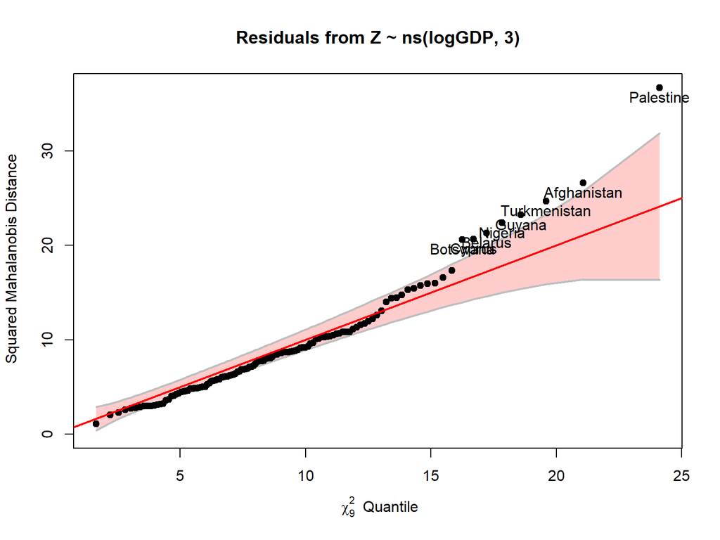

Figure 12: Chi-square QQ plot of squared Mahalanobis distances of residuals.

```r
# chi-square QQ plot of residual squared Mahalanobis distances
rownames(mod2$residuals) <- cc$country
cqplot(mod2, id.n = 8, main = "Residuals from Z ~ ns(logGDP, 3)")
```

```r
res <- resid(mod2)
D2 <- mahalanobis(res, colMeans(res), cov(res))
head(data.frame(D2 = round(sort(D2, decreasing = TRUE), 1)), 10)
```

```
#>                D2
#> Palestine    36.7
#> Afghanistan  26.6
#> Turkmenistan 24.7
#> Guyana       23.2
#> Nigeria      22.4
#> Belarus      21.3
#> Cyprus       20.7
#> Botswana     20.6
#> Lebanon      17.3
#> Pakistan     16.6
```

Most countries follow the line closely, up to a $D^2$ of about 15. Only the upper tail is too heavy. Nine countries are beyond the 95th percentile of $\chi^2_9$ (16.9), where we would expect about six, and five are beyond the 99th percentile (21.7), where we would expect about one. Only Palestine, at 36.7, is far outside the confidence band.

$D^2$ does not simply reward doing very well or very badly. It picks out unusual *combinations*. Guyana makes the point: it has by far the lowest PC1 score in Figure 11, but it is only fourth here. It is below its prediction on all nine outcomes, by 1.3 to 4.3 residual SDs, but a shortfall on everything at once runs along the direction in which the residuals usually vary. The others on the list are more out of pattern, and they fall into a few groups:

- **Conflict and crisis.** Palestine has much more electricity, doctors and safe water than its GDP predicts (2.2 to 3.4 SD), and low maternal mortality, yet its child mortality is *worse* than predicted. Afghanistan has the lowest life satisfaction in the data (1.4 on the 0–10 ladder, 3.6 SD below prediction) but is above prediction on electricity. Lebanon also combines low life satisfaction with better than expected doctors and life expectancy.
- **Resource economies.** Nigeria’s life expectancy is 4.2 SD below prediction, and Botswana is more than 3 SD below on both electricity and life satisfaction. Turkmenistan is in the next group too.
- **Mortality measures that disagree.** Turkmenistan is 2.3 SD *worse* than predicted on child mortality but 2.0 SD *better* on maternal mortality. Belarus is 2 to 3 SD better on all three mortality measures, and yet below prediction on life expectancy. Cyprus is there for one number, a maternal mortality of 68 per 100,000 births, 2.6 SD worse than predicted.

The last group raises the question of data quality. Are these real differences, or artifacts of how the indicators are estimated and reported? The maternal mortality of Turkmenistan (5 per 100,000) and Belarus (1 per 100,000), and of Cyprus in the other direction, are worth treating with some caution.

Old data are not the main explanation. In these 121 countries the values are nearly all recent. Maternal mortality is from 2020 for every country, and all the others but doctors and life satisfaction are from 2021 or later. The notable exceptions are the ones already mentioned: Guyana’s life satisfaction value is from 2011, and Palestine’s doctors value is from 2018, well before its GDP value.

### Influence

An outlier need not affect the fit very much. Influence depends on both the size of a country’s residual and its *leverage*, how far its log GDP is from the rest. Figure 13 plots these two against each other, with measures generalized to the multivariate case, on log scales. Each circle’s area shows Cook’s distance, the overall influence on the coefficients $\mathbf{B}$. The dashed diagonal lines mark constant values of the product of leverage and residual.

```
#>                                   H          Q     CookD          L          R
#> Afghanistan              0.07634399 0.26003970 0.5806847 0.08265414 0.28153306
#> Central African Republic 0.19267397 0.06432966 0.3625435 0.23865695 0.07968238
#> Guyana                   0.04460342 0.21186205 0.2764058 0.04668577 0.22175299
#> Ireland                  0.16841401 0.10499612 0.5172224 0.20252146 0.12626009
#> Luxembourg               0.15614190 0.11880095 0.5425818 0.18503336 0.14078309
#> Palestine                0.02686037 0.32295292 0.2537331 0.02760177 0.33186699
#> Singapore                0.19482894 0.04176286 0.2379959 0.24197211 0.05186830
#> Turkmenistan             0.01616336 0.21232338 0.1003819 0.01642891 0.21581162
```

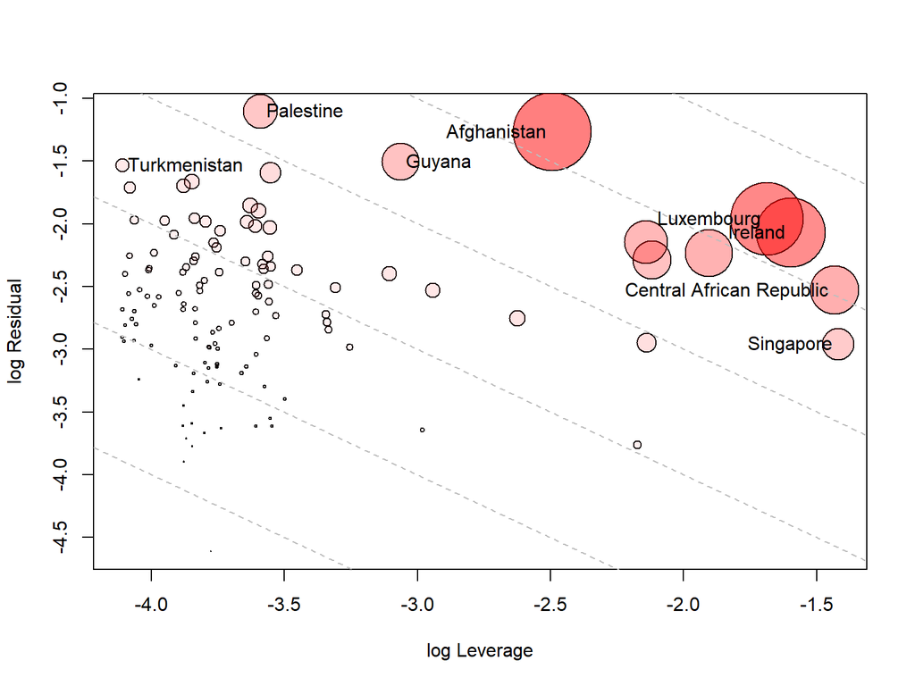

Figure 13: Influence plot for the MLM. Circle area shows Cook’s distance; dashed lines mark constant values of the product of leverage and residual.

```r
# mvinfluence supplies the influencePlot() method for "mlm" objects
library(mvinfluence)
influencePlot(mod2, id.n = 4, type = "LR")
```

Most of the outliers are at the left: Palestine, Turkmenistan, Nigeria and Belarus have large residuals but little leverage, because their incomes are in the middle of the range. With only GDP as a predictor, the high-leverage countries are simply the ones at the two ends of the income range. On the right, these are the poorest countries, the Central African Republic, Mozambique and Malawi (about $1,100 to $1,600), and the richest, Singapore, Ireland, Luxembourg and Qatar (above $110,000). The three large unlabeled circles in the plot are Mozambique, Malawi and Qatar.

Afghanistan has the most influence, because it combines the two: it is poor (about $2,000) and has a large residual. Next are Luxembourg and Ireland. This is a concern, because GDP is at its least meaningful for countries like these, where it is inflated by the profits of multinational firms and financial flows. Yet these few countries help to set the top end of the spline curve, and so the residuals of everyone else nearby. Likewise, Mozambique, the surprise in the last section, is the second-poorest country in the data, where the fit is least well anchored.

### Do they matter?

Table 3 repeats the main analyses without these countries: first Nigeria and Guyana, the two points noted in Figure 9, then the ten largest values of $D^2$, then the eight largest values of Cook’s distance.

**Show the code for refitting without the unusual countries**

```r
# refit the GDP model without some countries, standardizing the responses again
refit <- function(drop = character()) {
  d <- cc[!(cc$country %in% drop), ]
  Zd <- scale(as.matrix(d[, resp]))
  m1 <- lm(Zd ~ logGDP, data = d)
  m2 <- lm(Zd ~ ns(logGDP, 3), data = d)
  R <- cor(resid(m2))
  p <- prcomp(resid(m2))
  c("Countries" = nrow(d),
    "Pillai, spline vs. linear" = anova(m1, m2)$Pillai[2],
    "Average partial correlation" = mean(R[lower.tri(R)]),
    "ChildMort, Stillbirth" = R["ChildMort", "Stillbirth"],
    "ChildMort, LifeExp" = R["ChildMort", "LifeExp"],
    "Electricity, Doctors" = R["Electricity", "Doctors"],
    "Largest LifeSat correlation" = max(R["LifeSat", setdiff(resp, "LifeSat")]),
    "PC1 share of variance" = p$sdev[1]^2 / sum(p$sdev^2))
}
cook <- influence(mod2)$CookD
sensitivity <- cbind("All" = refit(),
                     "Without Nigeria, Guyana" = refit(c("Nigeria", "Guyana")),
                     "Without top 10 D²" = refit(names(sort(D2, decreasing = TRUE))[1:10]),
                     "Without top 8 Cook's D" = refit(cc$country[order(cook, decreasing = TRUE)][1:8]))
knitr::kable(round(sensitivity, 2))
```

Table 3: Main results for all countries, and after removing the most unusual ones.

|  | All | Without Nigeria, Guyana | Without top 10 D² | Without top 8 Cook’s D |
| --- | --- | --- | --- | --- |
| Countries | 121.00 | 119.00 | 111.00 | 113.00 |
| Pillai, spline vs. linear | 0.71 | 0.71 | 0.82 | 0.69 |
| Average partial correlation | 0.37 | 0.31 | 0.32 | 0.33 |
| ChildMort, Stillbirth | 0.73 | 0.68 | 0.71 | 0.71 |
| ChildMort, LifeExp | 0.64 | 0.55 | 0.56 | 0.59 |
| Electricity, Doctors | 0.60 | 0.59 | 0.46 | 0.57 |
| Largest LifeSat correlation | 0.26 | 0.24 | 0.28 | 0.27 |
| PC1 share of variance | 0.43 | 0.38 | 0.38 | 0.41 |

The strengths of the relations change, but the structure holds. Removing Nigeria and Guyana alone lowers the average partial correlation from .37 to .31, and child mortality with life expectancy from .64 to .55. So those two points were indeed adding to that correlation, though it remains substantial. Removing the outliers lowers the correlation of electricity with doctors from .60 to .46, the largest change. But the mortality block stays strong, life satisfaction stays isolated, and curvature stays highly significant. If anything, the test for curvature gets stronger without the outliers. So these countries are worth looking at for their own sake, but they don’t account for the general picture.

## Does the covariance structure change with development?

Everything so far has been about the *means*: how the typical level of each outcome changes with income, and how far a country falls from that level. This section turns to the other part of the model, the residual covariance matrix $\boldsymbol{\Sigma}$. It holds the variance of each of the nine outcomes around its fitted curve, and the covariance of each pair of outcomes around theirs.

The MLM assumes there is just one $\boldsymbol{\Sigma}$, the same at every level of income. The partial correlations in Figure 8 and the biplot in Figure 10 rest on this too: each one summarizes the whole range with a single picture. But do the outcomes vary together in the same way among the poorest countries as among the richest? Knowing that Malawi does better than expected on child mortality may tell you something different from knowing the same about Ireland.

To check this I divide the countries into three equal groups by income, up to about $13,000 (Low), up to about $41,000 (Middle) and above that (High), and compare the covariance matrices of their residuals using Box’s M test.

```r
# Equality of residual covariance matrices across GDP terciles
res <- resid(mod2)
bm <- boxM(res, cc$income)
bm
```

```
#>
#>  Box's M-test for Homogeneity of Covariance Matrices
#>
#> data:  res by cc$income
#> Chi-Sq (approx.) = 262.5299, df = 90, p-value = < 2.2e-16
```

The hypothesis of equal covariance matrices is strongly rejected ($\chi^2 = 262.5$, df = 90, $p < 10^{-15}$). This test is known to be sensitive to non-normality, and we have already seen that the residuals have heavy tails, so the small $p$-value alone doesn’t say how much the matrices differ. Figure 14 shows that, using the log determinant of each matrix, a one-number summary of how much multivariate scatter it describes. The High group stands well apart from the other two.

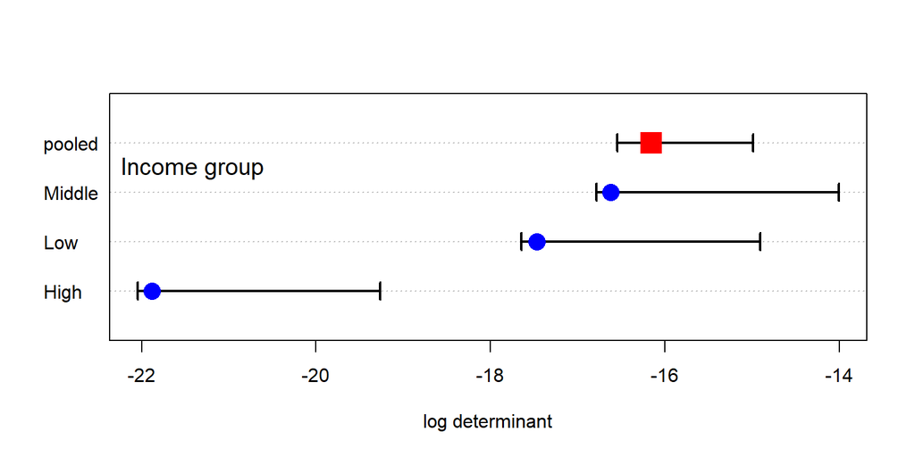

Figure 14: Log determinants of the residual covariance matrices by income group, with the pooled matrix for comparison.

```r
plot(bm, gplabel = "Income group")
```

A determinant mixes two things, though: how much each outcome varies, and how strongly the outcomes are correlated. Table 4 pulls these apart. Going up the income scale, the total residual variance steadily shrinks. But the correlations don’t follow it. They are weakest in the Middle group. That is why the Middle group has the largest determinant, even though the Low group has more total variance. The High group has the smallest determinant for both reasons: it has the least variance and the strongest correlations. Among the rich countries, the residuals come closest to differing along a single dimension.

```r
res_inc <- split(as.data.frame(res), cc$income)
data.frame(`Log determinant` = bm$logDet[names(res_inc)],
           `Total variance` = sapply(res_inc, \(d) sum(sapply(d, var))),
           `Average correlation` = sapply(res_inc, \(d) {
             r <- cor(d)
             mean(r[lower.tri(r)])
           }),
           `PC1 share` = sapply(res_inc, \(d) {
             e <- eigen(cov(d))$values
             e[1] / sum(e)
           }),
           check.names = FALSE) |>
  round(2) |>
  knitr::kable()
```

Table 4: Summaries of the residual covariance matrix in each income group: the log determinant, total variance, average correlation among the outcomes, and share of variance on the first principal component.

|  | Log determinant | Total variance | Average correlation | PC1 share |
| --- | --- | --- | --- | --- |
| Low | -17.47 | 2.93 | 0.41 | 0.51 |
| Middle | -16.62 | 2.17 | 0.27 | 0.36 |
| High | -21.88 | 1.73 | 0.47 | 0.55 |

Table 5 gives the residual standard deviation of each outcome. The outcomes don’t all change the same way. Electricity (.75 to .22), doctors (.66 to .30) and life satisfaction (.70 to .38) narrow sharply with income, and life expectancy does so between the Low and Middle groups. Rich countries are simply more alike on these. The mortality measures hardly change, schooling widens just a little, and water goes the other way (.39 to .57).

```r
sapply(res_inc, \(d) sapply(d, sd)) |>
  round(2) |>
  knitr::kable()
```

Table 5: Residual standard deviation of each outcome, by income group. The outcomes were standardized, so these are in units of the SD of each outcome over all countries.

|  | Low | Middle | High |
| --- | --- | --- | --- |
| ChildMort | 0.40 | 0.50 | 0.42 |
| Stillbirth | 0.41 | 0.46 | 0.44 |
| MatMort | 0.52 | 0.57 | 0.48 |
| Doctors | 0.66 | 0.43 | 0.30 |
| LifeExp | 0.64 | 0.42 | 0.41 |
| SchoolYrs | 0.54 | 0.55 | 0.59 |
| Electricity | 0.75 | 0.40 | 0.22 |
| Water | 0.39 | 0.43 | 0.57 |
| LifeSat | 0.70 | 0.62 | 0.38 |

Some of this comes from the measurements rather than the countries. Electricity has a hard ceiling: 98% of the High group and 80% of the Middle group have values of 99.5% or more, against 27% of the Low group. The logit spreads out the values near 100%, but it can’t separate countries that all report the same number, so there is little left to vary. Water is the reverse. Only 42% of the High group is at that level, and the logit stretches the differences among the rest. Even so, the ceiling is not the whole story. With electricity left out, Box’s test is still highly significant ($\chi^2 = 207.6$, df = 72).

Figure 15 shows both kinds of change, for four of the outcomes. A change in the *size* of an ellipse along an axis is a change in variance. In the panels with doctors, the High ellipse is much narrower in the doctors direction, and the Low ellipse is much wider. A change in its *tilt* is a change in correlation. For example, doctors and water are positively related in the Low group (.52), but unrelated in the High group ($-.01$), so the ellipses in that panel cross. Child mortality and life expectancy are very tightly linked in the Low group (.85), less so in the High group (.62) and least in the Middle group (.46).

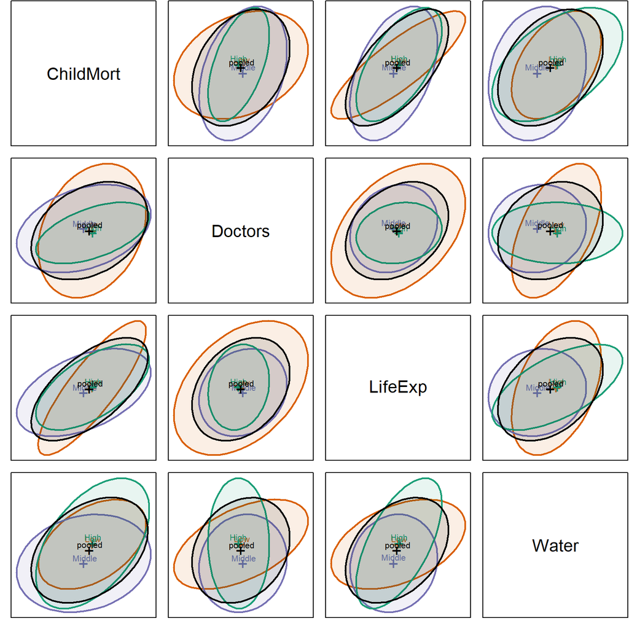

Figure 15: Residual covariance ellipses by income group, for four outcomes: Low (orange), Middle (purple), High (green) and pooled (black).

```r
covEllipses(res, cc$income, variables = c("ChildMort", "Doctors", "LifeExp", "Water"),
            fill = TRUE, fill.alpha = 0.1, pooled = TRUE,
            col = c("#d95f02", "#7570b3", "#1b9e77", "black"))
```

The correlations also qualify two earlier conclusions, with the caution that each is based on only 40 or so countries. The “state capacity” link among electricity, doctors and maternal mortality is strongest among the poorest countries, with correlations of .72 to .75 in the Low group, against .30 to .44 in the Middle group and .43 to .56 in the High group. The other is more surprising. Life satisfaction seemed to go its own way, but that is true mainly below about $41,000. Its largest correlation in either the Low or the Middle group is about .35, whereas in the High group it reaches .62 with schooling and .50 with maternal mortality. Among rich countries, those doing better than their income predicts on these outcomes do tend to be happier too.

So the single $\boldsymbol{\Sigma}$ of the MLM is an average over three rather different matrices. This doesn’t invalidate what came before. The fitted curves don’t depend on it, and the pooled correlations are still a fair overall summary. But the multivariate tests are more approximate than they look, and a statement such as “these outcomes are correlated, given GDP” should be read as true on average, not at every level of income.

What can be done about it? The first remedy is one already used here: transformations, which often make variances more similar, but which can’t do anything about a ceiling. For that, it might be better to drop or recode a measure like electricity, which has little left to say among the richer countries. Beyond that, one can test with methods that don’t rely on equal covariance matrices, such as the bootstrap, or analyze the income groups separately, at the cost of even smaller samples. Or one can model the dispersion directly, allowing the variances to depend on GDP, as well as the means.

## Whole-data views

What if we started afresh, and took a visual look at the life aspect variables simply as a data matrix, using the standardized values in `Z`? There are no models, residuals or ellipses here: just 121 rows for the countries, 9 columns for the outcomes, and a color for each cell.

A display like this is only as good as the order of its rows and columns. Countries listed alphabetically would give you confetti. So I use the idea of effect ordering (Friendly and Kwan 2003): arrange the display according to the effect you want to see. Figure 16 sorts the countries by GDP per capita, and the outcomes by their correlation with log GDP, from child mortality (.88) on the left to electricity (.79) on the right. Values beyond $\pm 2.5$ are given the darkest color.

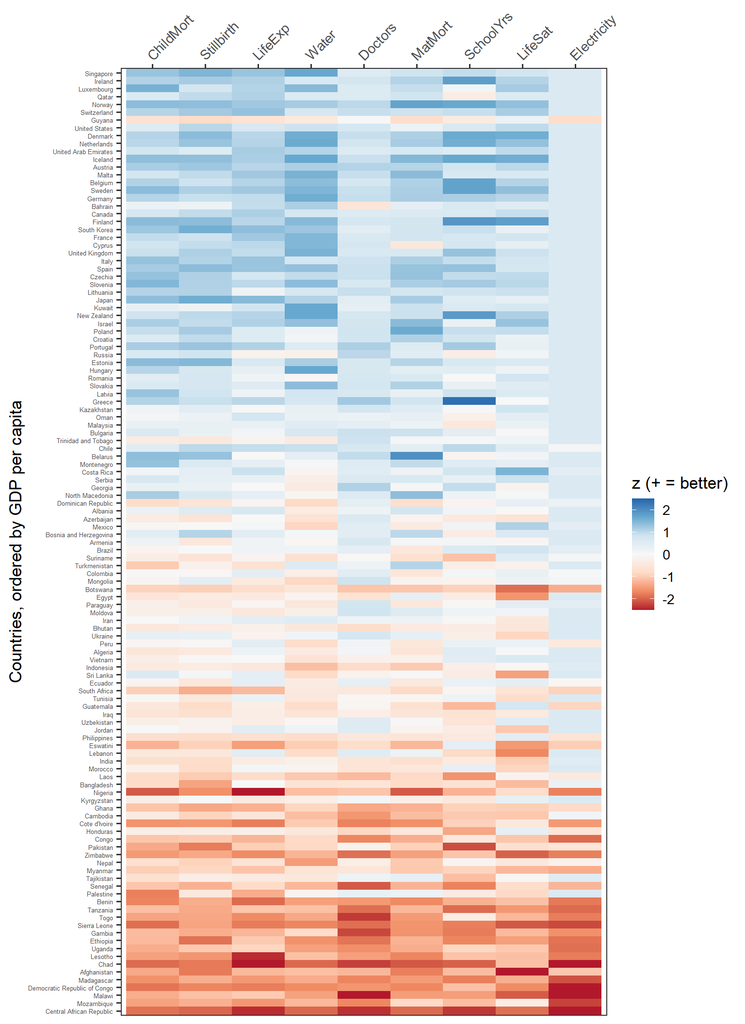

Figure 16: Ordered heatmap: countries sorted by GDP, responses by correlation with GDP.

```r
# countries (rows) ordered by GDP, responses (cols) ordered by correlation with GDP
var_ord <- names(sort(cor(Z, cc$logGDP)[, 1], decreasing = TRUE))
Zlong <- data.frame(country = cc$country, logGDP = cc$logGDP, Z) |>
  pivot_longer(all_of(resp), names_to = "response", values_to = "z") |>
  mutate(country = reorder(country, logGDP),
         response = factor(response, levels = var_ord),
         z = pmax(pmin(z, 2.5), -2.5))

ggplot(Zlong, aes(response, country, fill = z)) +
  geom_tile() +
  scale_fill_distiller(palette = "RdBu", direction = 1, limits = c(-2.5, 2.5),
                       name = "z (+ = better)") +
  scale_x_discrete(position = "top") +
  labs(x = NULL, y = "Countries, ordered by GDP per capita") +
  theme(axis.text.y = element_text(size = 5),
        axis.text.x = element_text(angle = 45, hjust = 0),
        panel.grid = element_blank())
```

This is the OWID chart again, with all its panels folded into one picture. The main message is just as immediate: blue at the top, red at the bottom. In the richest third of countries, 96% of the cells are above average, and in the poorest third only 10% are.

But it can do something the small multiples cannot. In Figure 1, a country is an anonymous dot in each panel, and there is no way to follow it from one panel to the next. Here each country is a row, so you can read across it. Against the smooth gradient, the exceptions are rows or cells that are off-color for their position:

- **Whole rows.** Guyana sits near the top, with GDP per capita of about $84,000, in a pale orange band among the blue rows of the richest countries. Near the bottom, Nigeria and Kyrgyzstan are neighbors, with nearly the same income (about $8,000). Nigeria is one of the reddest rows in the figure, and Kyrgyzstan is nearly white.
- **Single cells.** Lesotho and Chad stand out on life expectancy, Malawi on doctors, and Afghanistan on life satisfaction. At the other extreme, Greece has the darkest blue cell in the figure, for schooling. Botswana is off-color mainly in its last two columns.
- **Whole columns.** Electricity looks different from the rest. Its upper two-thirds is nearly one uniform pale blue, and nearly all its color is at the bottom, where Chad and Malawi are darkest. This is the ceiling again: 73 of the 121 countries share the top value, 100%, which is only $z = 0.61$. Life satisfaction, in the column beside it, has its own pattern. No country in the richest third is below average on it, but some in the middle, such as Egypt and Sri Lanka, are much lower than their neighbors.

Many of these are the same countries that came out of the residual PCA and the outlier analysis: Guyana, Nigeria, Kyrgyzstan, Botswana, Afghanistan. There they took a fitted model to find. Here you can simply see them, once the matrix is put in a useful order. Of course, the model tells you *how far* out of line they are, and the heatmap only tells you where to look.

Figure 17 shows the same matrix another way. Now each country is a line, running across the outcomes in the same order, and colored by GDP.

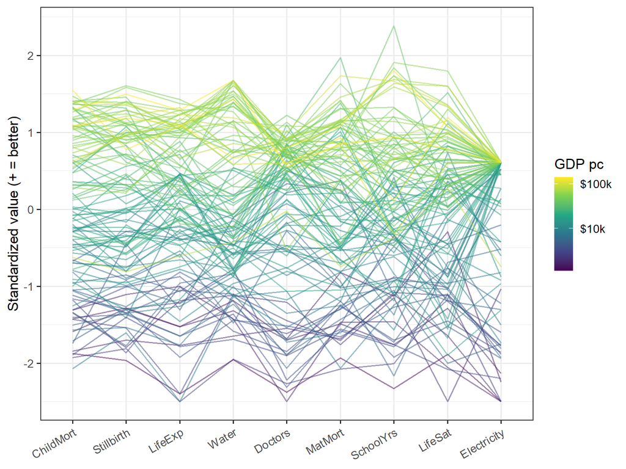

Figure 17: Parallel coordinates of standardized responses, colored by GDP.

```r
Zlong |>
  ggplot(aes(response, z, group = country, colour = logGDP)) +
  geom_line(alpha = 0.5) +
  scale_colour_viridis_c(name = "GDP pc", breaks = 3:5,
                         labels = c("$1k", "$10k", "$100k")) +
  labs(x = NULL, y = "Standardized value (+ = better)") +
  theme(axis.text.x = element_text(angle = 30, hjust = 1))
```

With 121 lines the middle of this plot is a tangle, and you can’t identify any particular country. It is better for seeing the overall shape. The colors stack up in order, with the rich countries in yellow and green on top and the poor ones in purple at the bottom, and that is the common factor once more. The lines stay in their bands at the two extremes and cross most in the middle incomes. The most striking feature is at the right: the lines from nearly all the richer countries converge on a single point at electricity, the ceiling seen as a fan. A lone yellow line well below the other rich countries is Guyana, and the line that spikes up at schooling is Greece.

## What I learned

I have been drawing HE plots for a long time, but this example still taught me some things. It has one quantitative predictor and many responses, a setup I had not thought much about, and which at first seems to leave an HE plot with nothing to do.

**A spline rescues the degenerate ellipse.** With $\log(\text{GDP})$ as a single 1-df term, the H “ellipse” is only a line. Giving GDP a few more degrees of freedom lets it open up, and how far it opens shows how far the relations depart from a straight line. So what began as a trick to get a proper ellipse also gives a visual check for curvature. In Figure 6 the GDP ellipse stays a thin cigar in most panels, and fattens where doctors are involved.

**A grouping variable gives the plot something to compare.** Adding region is what made the HE plots interesting. It gave a second H ellipse, a contrast between an effect that is nearly one-dimensional and one that is not, and a question I could not have asked of GDP alone: how do countries differ *at the same income*? It also turned the problem into a MANCOVA, which comes with its caveat about unequal slopes.

**The defaults can undo the adjustment.** This is the one I would most like others to know about. The region H ellipse is adjusted for GDP, but the region means that `heplot()` draws by default are not, and neither are the scores that `candisc()` plots. Left alone, these displays mostly show income all over again, with Can1 correlating $-0.86$ with log GDP. Using the residuals from the GDP model as the responses fixes this, for the display at least.

**PCA can be aimed.** A PCA of the outcomes rediscovers income, which we already knew. Taking out the known common factor first turns the same tool toward a better question: who does more, or less, than their money predicts?

**Rescaling makes panels comparable.** The development profiles (Figure 3) came from wanting to compare across the OWID panels. Just rescaling each fitted curve to run from 0 to 1 was enough to show a sequence I couldn’t see in the separate panels, though Table 1 shows how much that sequence depends on the scale of each outcome.

## Lessons

Small multiples like Figure 1 show the marginal relations very well. Multivariate displays add the joint structure: what’s common, what’s left over, and who’s unusual. Getting there takes some work up front. Orienting, transforming and standardizing the variables comes first, and these are not neutral steps. As Table 1 shows, doctors go from second to last in the development sequence just by changing the scale, so it is as well to know what your scales are saying.

The largest lesson is to take out what you already know. The raw correlations average .81 and show little structure, because GDP drives them all. Controlling for GDP drops the average to .37, and the structure appears. Nearly every multivariate display here became more interesting once income was out of the way.

But a residual is only relative to its model. Guyana looks like a failure because its GDP changed faster than everything else, and Palestine looks like a success partly because its GDP fell. Change the curve from a spline to a quadratic, and 9 of the 24 countries in Figure 11 change too. A ranking like this one says as much about GDP, and about the shape of the curve, as it does about the countries.

The same care applies to summaries over the whole range of incomes. Life satisfaction seemed to go its own way, nearly independent of everything else once GDP was controlled. That holds for most of the world, but among the richest third of countries it is linked with schooling and maternal mortality. A single covariance matrix is an average, and here it averages over rather different matrices.

Finally, the models and the pictures need each other. The sorted heatmap in Figure 16 shows many of the same exceptions that the outlier analysis found, with no model at all. The model says how far out of line a country is, and how much to believe it. The picture shows you where to look, and it keeps you honest about what the model has left out.

## Acknowledgments and data

Data: Our World in Data (2026) (CC-BY), from UN IGME, UN MMEIG, WHO/UNICEF, UN WPP, UNESCO, UNDP, Gallup and the World Bank. Thanks to Max Roser.

## References

Friendly, Michael. 2007. “HE Plots for Multivariate Linear Models.” *Journal of Computational and Graphical Statistics* 16 (2): 421–44. https://doi.org/10.1198/106186007X208407.

Friendly, Michael. 2024. *Visualizing Multivariate Data and Models in R*. Chapman & Hall/CRC Press. https://friendly.github.io/Vis-MLM-book/.

Friendly, Michael. 2026. *mvinfluence: Influence Measures and Diagnostic Plots for Multivariate Linear Models*. https://doi.org/10.32614/CRAN.package.mvinfluence.

Friendly, Michael, and John Fox. 2026. *candisc: Visualizing Generalized Canonical Discriminant and Canonical Correlation Analysis*. https://CRAN.R-project.org/package=candisc.

Friendly, Michael, John Fox, and Georges Monette. 2026. *heplots: Visualizing Tests in Multivariate Linear Models*. https://CRAN.R-project.org/package=heplots.

Friendly, Michael, and Ernest Kwan. 2003. “Effect Ordering for Data Displays.” *Computational Statistics and Data Analysis* 43 (4): 509–39. https://doi.org/10.1016/S0167-9473(02)00290-6.

Hastie, Trevor, and Robert Tibshirani. 1986. “Generalized Additive Models.” *Statistical Science* 1 (3): 297–310. https://doi.org/10.1214/ss/1177013604.

Nelder, J. A., and R. W. M. Wedderburn. 1972. “Generalized Linear Models.” *Journal of the Royal Statistical Society, Series A* 135 (3): 370–84. https://doi.org/10.2307/2344614.

Our World in Data. 2026. *Our World in Data*. [Https://ourworldindata.org/](https://ourworldindata.org/).